# Matlab Cholesky Decomposition Variance-Covariance Two Dimensional Normal Shocks

[Fan Wang](https://fanwangecon.github.io/)

2020-10-23

# 1 Cholesky Decomposition Correlated Bivariate Normal from IID Random Draws

> Go to the [**MLX**](https://github.com/FanWangEcon//M4Econ/blob/master/panel/timeseries//fs_autoregressive.mlx), [**M**](https://github.com/FanWangEcon//M4Econ/blob/master/panel/timeseries//htmlpdfm/fs_autoregressive.m), [**PDF**](https://github.com/FanWangEcon//M4Econ/blob/master/panel/timeseries//htmlpdfm/fs_autoregressive.pdf), or [**HTML**](https://fanwangecon.github.io//M4Econ/panel/timeseries//htmlpdfm/fs_autoregressive.html) version of this file. Go back to [fan](http://fanwangecon.github.io/)’s [MEconTools](https://fanwangecon.github.io/MEconTools/) Package, [Matlab Code Examples](https://fanwangecon.github.io/M4Econ/) Repository ([bookdown site](https://fanwangecon.github.io/M4Econ/bookdown)), or [Math for Econ with Matlab](https://fanwangecon.github.io/Math4Econ/) Repository ([bookdown site](https://fanwangecon.github.io/Math4Econ/bookdown)).

Draw two correlated normal shocks using the MVNRND function. Draw two correlated normal shocks from uniform random variables using Cholesky Decomposition.

- [fs_cholesky_decomposition](https://fanwangecon.github.io/M4Econ/simulation/normal/htmlpdfm/fs_cholesky_decomposition.html)
- [fs_cholesky_decomposition_d5](https://fanwangecon.github.io/M4Econ/simulation/normal/htmlpdfm/fs_cholesky_decomposition_d5.html)
- [fs_bivariate_normal](https://fanwangecon.github.io/M4Econ/simulation/normal/htmlpdfm/fs_bivariate_normal.html)

## 1.1 Positively Correlated Scores MVNRND

We have English and Math scores, and we draw from a bivariate normal distribution, assuming the two scores are positively correlatd. These are $x_1$ and $x_2$.

```
% mean, and varcov
ar_mu = [70,80];
mt_varcov = [8,5;5,5];
% Generate Scores
rng(123);
N = 10000;
mt_scores = mvnrnd(ar_mu, mt_varcov, N);
% graph
figure();
scatter(mt_scores(:,1), mt_scores(:,2));
ylabel('English Scores');
xlabel('Math Scores')
grid on;
```

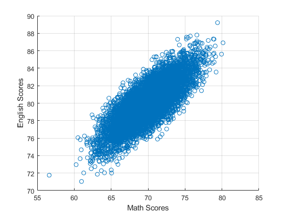

What are the covariance and correlation statistics?

```
disp([num2str(cov(mt_scores(:,1), mt_scores(:,2)))]);

8.0557      5.0738
5.0738      5.0638

disp([num2str(corrcoef(mt_scores(:,1), mt_scores(:,2)))]);

      1     0.79441
0.79441           1
```

## 1.2 Bivariate Normal from Uncorrelated Draws via Cholesky Decomposition

We can get the same results as above, without having to explicitly draw from a multivariate distribution by (For more details see [Train (2009)](https://eml.berkeley.edu/~train/distant.html)):

1. Draw 2 uniform random iid vectors.
2. Convert to normal iid vectors.
3. Generate the test scores as a function of the two random variables, using Cholesky matrix.

*First*, draw two uncorrelated normal random variables, with mean 0, sd 1, $\eta_1$ and $\eta_2$.

```
% Draw Two Uncorrelated Normal Random Variables
% use the same N as above
rng(123);
% uniform draws, uncorrelated
ar_unif_draws = rand(1,N*2);
% normal draws, english and math are uncorreated
% ar_draws_eta_1 and ar_draws_eta_2 are uncorrelated by construction
ar_normal_draws = norminv(ar_unif_draws);
ar_draws_eta_1 = ar_normal_draws(1:N);
ar_draws_eta_2 = ar_normal_draws((N+1):N*2);
% graph
figure();
scatter(ar_draws_eta_1, ar_draws_eta_2);
ylabel('iid eta 1 draws');
xlabel('iid eta 2 draws')
grid on;
```

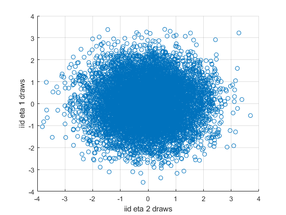

```
% Show Mean 1, cov = 0
disp([num2str(cov(ar_draws_eta_1, ar_draws_eta_2))]);

  0.99075   0.0056929
0.0056929     0.98517

disp([num2str(corrcoef(ar_draws_eta_1, ar_draws_eta_2))]);

        1   0.0057623
0.0057623           1
```

*Second*, now using the variance-covariance we already have, decompose it, we will have:

- $\displaystyle \begin{array}{l} c_{aa} \,,\,\,0\\ c_{ab} \,,\,\,c_{bb} \end{array}$

```
% Choesley decompose the variance covariance matrix
mt_varcov_chol = chol(mt_varcov, 'lower');
disp([num2str(mt_varcov_chol)]);

2.8284           0
1.7678      1.3693

% The cholesky decomposed matrix factorizes the original varcov matrix
disp([num2str(mt_varcov_chol*mt_varcov_chol')]);

8           5
5           5
```

*Third*, We can get back to the original $x_1$ and $x_2$ variables:

- $\displaystyle x_1 =\mu_1 +c_{aa} *\eta_1$
- $\displaystyle x_2 =\mu_2 +c_{ab} *\eta_1 +c_{bb} *\eta_2$

```
% multiple the cholesky matrix by the eta draws
mt_scores_chol = ar_mu' + mt_varcov_chol*([ar_draws_eta_1; ar_draws_eta_2]);
mt_scores_chol = mt_scores_chol';
% graph
figure();
scatter(mt_scores_chol(:,1), mt_scores_chol(:,2));
ylabel('English Scores Chol from iid Draws = m1 + c\_aa*eta\_1');
xlabel('Math Scores Chol from iid Draws = m2 + c\_ab*eta\_1 + c\_bb*eta\_2')
grid on;
```

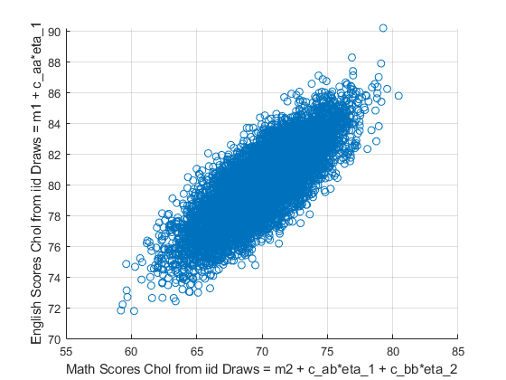

```
disp([num2str(cov(mt_scores_chol(:,1), mt_scores_chol(:,2)))]);

 7.926      4.9758
4.9758      4.9708

disp([num2str(corrcoef(mt_scores_chol(:,1), mt_scores_chol(:,2)))]);

      1     0.79272
0.79272           1
```